# Fatty15

Masters of Marketing Disguised as Science

John | The John & Calvin Podcast  
This presentation reflects the personal opinions of the speaker, based on publicly available information as of September 18, 2025. It is intended as commentary and critique for educational purposes only. The content does not provide medical advice. No affiliation with, or endorsement by, Fatty15 or related entities is intended or implied.

### Fatty15: Better than Everything

“100+ peer-reviewed studies have been published by independent scientists throughout the world on the benefits of C15:0, including the pure C15:0 ingredient in fatty15.”

“C15:0 is emerging as the first essential fatty acid to be discovered in over 90 years.”

“C15:0 is a pleiotropic nutrient with multiple dose-dependent mechanisms of action.”

“An estimated 1 in 3 people may have Cellular Fragility Syndrome.”

“Fatty15 fixes C15:0 deficiencies & reverses Cellular Fragility Syndrome”

“Clinical Trial Results: Fatty15 Can Treat Nutritional C15:0 Deficiencies”

“lower inflammation, and repair mitochondrial function”

“C15:0 helps support and balance mood”

“C15:0 helps support healthy cells by targeting key hallmarks of aging”

“helps support your metabolism and healthy weight on a cellular level”

“The Longevity Nutrient” “fatty15 has emerged as a leading longevity-extending geroprotector”

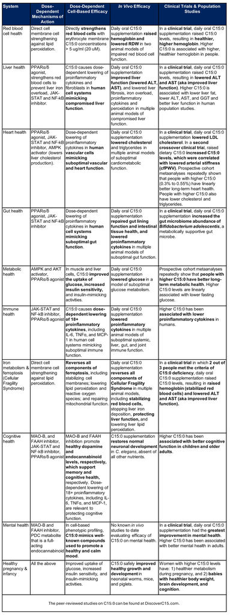

### Quick Definitions

- Fat
  - One of the three main nutrients in food (with protein and carbohydrate).
  - Fats are made of fatty acids and glycerol.
- Fatty Acid
  - Components of fat. Made of a chain of carbon atoms with hydrogen attached.
  - Different fatty acids give fats their properties (solid or liquid at room temperature).
- Saturated Fat
  - Fat made mostly of saturated fatty acids (no double bonds in carbon chain)
  - Solid at room temperature. Found in butter, cheese, meat, some tropical oils
- C15:0 (also called C15, pentadecanoic acid, or **fatty15**)
  - A specific type of saturated fatty acid with 15 carbon atoms.
  - fatty15 = C15:0
- C17:0: similar as above, but 17 carbons.

### Sources of C15 / C17

- Exogenous (diet)
- C15 stronger dietary biomarker for dairy intake
- Endogenous / microbial fermentation
  - both, but stronger for c15
- Vegans show detectable levels of both

| Food (serving) | C15:0 (mg) | C17:0 (mg) |
| --- | --- | --- |
| Butter, unsalted (1 Tbsp; ~11.5 g fat) | 121 | 70 |
| Whole milk (1 cup; ~7.9 g fat) | 83 | 48 |
| Cheddar cheese (1 oz; ~9.5 g fat) | 100 | 58 |
| Beef fat (1 Tbsp; ~12.8 g fat) | 55 | 106 |
| Salmon, Atlantic, farmed, **raw** (3 oz) | 39 | 37 |
| Cod, Pacific, **cooked** (3 oz) | 0 | 0 |

<sub>sources: [1](https://tools.myfooddata.com/nutrition-facts/173430/wt2) [2](https://tools.myfooddata.com/nutrition-facts/171265/wt1) [3](https://tools.myfooddata.com/nutrition-facts/173414/wt4) [4](https://tools.myfooddata.com/nutrition-facts/171400/wt1) [5](https://loinc.org/48366-9/) [6](https://www.hmdb.ca/metabolites/hmdb02259) [7](https://tools.myfooddata.com/nutrient-ranking-tool/15-0/fish/highest) [8](https://tools.myfooddata.com/nutrient-ranking-tool/17-0/fish/highest) [9](https://lipidworld.biomedcentral.com/articles/10.1186/s12944-025-02517-6) [10](https://pmc.ncbi.nlm.nih.gov/articles/PMC6461718/) [11](https://pubmed.ncbi.nlm.nih.gov/16484525/) [12](https://pmc.ncbi.nlm.nih.gov/articles/PMC6272531/) [13](https://pmc.ncbi.nlm.nih.gov/articles/PMC11983864/)</sub>

### The fatty15 Origin Story

After analyzing thousands of samples collected over the span of about 50 years, Venn-Watson and her team were able to determine what the healthiest aging dolphins had in common.  
“We thought it was going to be omega-3′s, because all they eat are fish.  
And instead, it was C15:0, a saturated fatty acid I had never heard of,” she says. - Published May 24, 2025

[Modified fish diet shifted serum metabolome and alleviated chronic anemia in bottlenose dolphins (Tursiops truncatus): Potential role of odd-chain saturated fatty acids](https://journals.plos.org/plosone/article?id=10.1371%2Fjournal.pone.0230769)

### Dolphin Research to fatty15

**The Beginnings**

- **2008** — Venn-Watsons co-found [Epitracker](https://www.epitracker.com/dolphinhuman.html) to mine Navy dolphin data for translatable molecules
- **May 7, 2015** — Navy issues **Notice of Intent** to grant Epitracker a (partial) exclusive patent license (tech transfer trigger) [[Federal Reg.](https://public-inspection.federalregister.gov/2015-10990.pdf?1430916369=)].
- **Jul 22, 2015** — Dolphin study highlights **C17:0** (heptadecanoic acid) links to metabolic markers [[PLOS ONE](https://journals.plos.org/plosone/article?id=10.1371%2Fjournal.pone.0132117)].

**Commercialization**

- Jan 7, 2015 / Dec 28, 2015 — Patents filed (granted Feb 7, 2017 / Jul 18, 2017) **C17:0 patents** by Navy/Stephanie Venn-Watson for diagnosis/therapy ([US 9,561,206](https://patents.google.com/patent/US20160193170A1/en)); supplementation ([US 9,707,199](https://patents.google.com/patent/US9707199B2/en)).
- April 2017 — US Navy grants Epitracker an [exclusive license](https://www.federalregister.gov/documents/2017/04/03/2017-06454/notice-of-intent-to-grant-exclusive-patent-license-epitracker-inc) covering those patents
- **2019** — Epitracker announces **Seraphina Therapeutics** as the commercialization spin-out ([Epitracker news](https://www.epitracker.com/news.html)).

**The Pivot to C15**

- **Nov 28, 2019** Pivot to **C15:0** — **US 2019/0358183 A1** publishes: **broadens to odd-chain FAs incl. C15:0**; frames **planned supplement/food ingredient** uses (first public C15 pivot appears **in IP**) ([Google Patents](https://patents.google.com/patent/US20190358183A1/en)).
- **Apr 7, 2020** — Dolphin metabolomics/anemia paper; **First published paper focusing on C15**. COI lists Epitracker/Seraphina ([PLOS ONE](https://journals.plos.org/plosone/article?id=10.1371/journal.pone.0230769)).

**C15 is Essential and Product Launch (same day publish/product launch)**

- **May 18, 2020** — *Scientific Reports* paper (founder-led) states C15:0 “potentially essential” (animal/cell work) [[Sci. Reports](https://www.nature.com/articles/s41598-020-64960-y)]  
  same-day **launch PR** positioning C15:0 as “new essential FA”, fundraising, & fall 2020 supplement plan [[PR Newswire](https://www.prnewswire.com/news-releases/seraphina-therapeutics-introduces-newly-discovered-potential-essential-saturated-fatty-acid-present-in-butter-301060418.html); trade press [[C&EN](https://cen.acs.org/business/start-ups/Seraphina-launches-new-fatty-acid/98/i20)]].
- **Nov 19, 2020** — **Soft-launch** of **fatty15** noted; **Jan 4, 2021** official DTC launch [[NutraIngredients](https://www.nutraingredients-usa.com/Article/2020/11/19/Fatty15-New-supplement-brand-brings-good-saturated-fat-from-US-Navy-dolphins-to-consumers/)], [[Launch PR](https://www.prnewswire.com/news-releases/meet-fatty15-a-supplement-derived-from-a-newly-discovered-essential-nutrient-helping-our-bodies-combat-age-related-breakdown-301199566.html)].
- **Jun 24, 2021** — **GRAS** status for FA15 (C15:0 ingredient) announced (opens **food** channel) [[Business Wire](https://www.businesswire.com/news/home/20210624005920/en/Seraphina-Therapeutics-Hits-Significant-Regulatory-Milestone-Earning-GRAS-Status-for-FA15)], [[FoodDive](https://www.fooddive.com/news/seraphina-therapeutics-fatty-acid-powder-gains-gras-status/602238/)].
- **Sep 14, 2021** — Patent on **C15:0 human dosing/uses** granted (commercial dosing claims) [[US 11,116,740](https://patents.google.com/patent/US11116740B2/en)].

### Dolphin Research to fatty15

**TEDx and more Publishing with Marketing Language Built-in**

- **Mar 27, 2022** — **TEDx San Diego** talk ties the dolphin story to human aging (brand awareness push, thought-leadership marketing) [[TED](https://www.ted.com/talks/stephanie_venn_watson_dvm_mph_save_the_dolphins_save_the_world)].
- **May 26, 2022** — **PLOS ONE** paper directly compares **C15:0 vs omega-3 (EPA)** across 12 primary human cell systems (positioning vs. incumbent category) [[PLOS ONE](https://journals.plos.org/plosone/article?id=10.1371%2Fjournal.pone.0268778)]. [“the essential, essential fatty acid”](https://www.biospace.com/new-study-from-seraphina-therapeutics-finds-that-a-good-saturated-fat-c15-0-is-better-broader-and-safer-than-omega-3#:~:text=,the%20essential%2C%20essential%20fatty%20acid)
- **Oct 30, 2023 — Nutrients:** **Review** asserting C15:0 as an **essential fatty acid** with **longevity-like** activities (comparisons to metformin/rapamycin). (brand narrative). [Nutrients](https://pubmed.ncbi.nlm.nih.gov/37960259/)
- **Jul 2024** — **Metabolites (review)** coins **“Cellular Fragility Syndrome”** & sets “optimal” C15:0 targets → **immediate trade coverage & branded newsletter**. [Metabolites](https://www.mdpi.com/2218-1989/14/7/355), [NutraIngredients](https://www.nutraingredients-usa.com/Article/2024/08/06/C15-0-may-hold-the-key-to-fixing-Cellular-Fragility-Syndrome/), [DiscoverC15 Newsletter PDF](https://www.discoverc15.com/wp-content/uploads/2024/07/Newsletter-93.pdf)

**fatty15 RCT Published.**

- **2024** — First human RCT with fatty15 appears (early clinical step) [[J. Nutrition](https://jn.nutrition.org/article/S0022-3166%2824%2900411-5/fulltext)].

**The Marketing and Ad Spend Significantly Increase**

- **May 2025** — Coordinated **“vs. Omega-3”** marketing (blog + ad campaign) explicitly leverages the 2022 paper [[Campaign explainer](https://fatty15.com/blogs/news/we-can-be-better-the-why-behind-fatty15-s-latest-ad-campaign)], [[“Deep Dive” blog](https://fatty15.com/blogs/news/deep-dive-fatty15-vs-omega-3-study)], [[FAQ advising swap](https://fatty15.com/pages/faqs)].
- **2025 — Paid media ramp (CTV + creators + affiliates):** [Roku Ads case study](https://advertising.roku.com/learn/resources/how-dtc-wellness-brand-fatty15-turned-tv-screens-into-shopping-carts-with-roku-ads-manager) (Jul 22); TV/CTV spots “Longevity” & “Age Without Breaking” ([iSpot 1](https://www.ispot.tv/ad/BIxY/fatty15-longevity), [iSpot 2](https://www.ispot.tv/ad/BGpK/fatty15-age-without-breaking-15-off-first-order)) (Jul 24 / Sep 10); creative highlighted by **Tinuiti**/**Myriad** ([Myriad blog](https://myriad.video/blog/creating-a-whimsical-video-for-fatty15/)) (Aug 26); plan to **double ad spend** ([Attribution case study](https://www.attributionapp.com/case-studies/fatty15/)); ongoing **podcast sponsorships** ([Crooked sponsors](https://crooked.com/sponsors/));  
  active **affiliate** + **Health Care Professional (aka Doctor) Affiliate** programs ([Affiliate](https://fatty15.com/pages/affiliate), [HCP Affiliate](https://fatty15.com/pages/hcpaffiliate)).

#### Early publications and patents emphasized C17. Switch to C15 appeared first in branding / patent filings, prior to publishing paper focusing on C15. More recently, marketing and ad spend significantly increases, science and evidence does not.

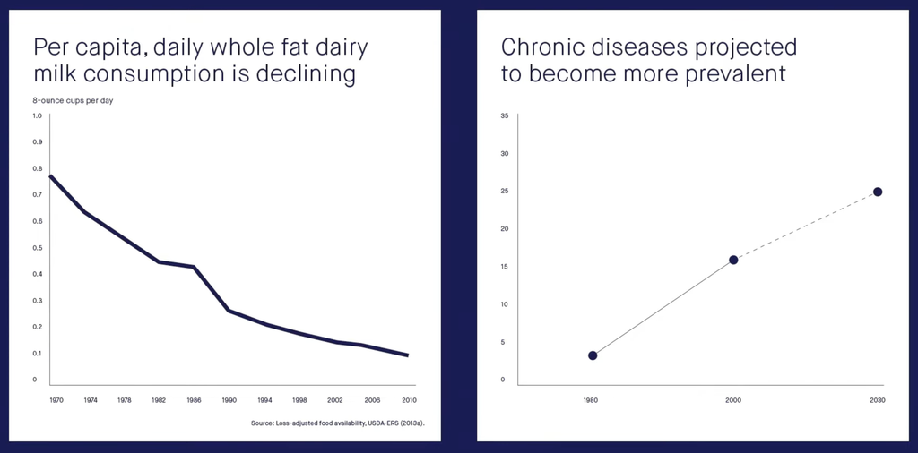

Source: [Venn-Watson TEDx Talk](https://www.youtube.com/watch?v=k1yRoeAeI68&t=4m21s)

# Patents

### Patents

[Seraphina Therapeutics (fatty15) holds over 60 patents on one single molecule. How?](https://finance.yahoo.com/news/groundbreaking-longevity-supplement-fatty15-catapults-120000204.html)

- A **natural molecule** cannot be patented “as found”
- Methods of use, dosing regimens, compositions, manufacture/purification, and target blood levels [can be patented](https://pmc.ncbi.nlm.nih.gov/articles/PMC4086272/)
- Patents are not proof of efficacy or regulatory approval, patents = right to exclude
- Human RCTs aren’t required. **Credible utility** & **enablement**
- First patents are on C17 in 2017. Not on C15.
- [C15:0 Patent appears in 2019](https://patents.google.com/patent/US20190358183A1/en): pre-grant US 2019/0358183 A1 (filed Aug 2019; pub Nov 2019) broadens from C17:0 to odd-chain FAs incl. C15:0, “planned supplement”/food uses & dosing ranges.
- [2020 Scientific Reports](https://www.nature.com/articles/s41598-020-64960-y) paper positions C15:0 as “potentially essential,” cites anti-inflammatory/dyslipidemia/fibrosis signals in models
- [Later-issued US 11,116,740](https://patents.google.com/patent/US11116740B2/en) claims administering C15:0 (e.g., mg/kg/day for ≥1 month) to alleviate states like oxidative stress, dyslipidemia, insulin resistance, incl. as food/beverage additives

Why so many?

- **Portfolio strategy:** The more patents the greater the ability to threaten/stop close competitors
- **Exclusivity messaging:** “patented”, leverage with retailers/investors, .

# Essential Fatty Acid

### Essential Fatty Acid

“**could it be essential**?”; [2020 Study](https://www.nature.com/articles/s41598-020-64960-y)

**“is emerging as an essential fatty acid”**; [2022 Study](https://journals.plos.org/plosone/article?id=10.1371/journal.pone.0268778)

**“(C15:0) is an essential odd-chain saturated fatty acid”**; [2023 Study](https://www.mdpi.com/2072-6643/15/21/4607)

**“essential”, “newly identified nutritional C15:0 deficiency syndrome (“Cellular Fragility Syndrome”)“**; [2024 Study](https://pubmed.ncbi.nlm.nih.gov/39057678/)

**“emerged as…essential…required by animals to support both early development and long-term health”, “supporting cognitive health”**; [2025 Study](https://www.mdpi.com/1422-0067/26/8/3746#B38-ijms-26-03746)

Every single author of all 5 of these studies is either a co-founder / equity holder / advisor / funded by / an employee of the company that makes and promotes fatty15.  
(except one recurring research collaborator from the U.S. Navy Marine Mammal Program)

# GRAS

### GRAS (Generally Recognized as Safe)

> FAQ: [“Is it safe to take when pregnant?”, “What is the recommended age to start taking fatty15?”](https://fatty15.com/pages/faqs)
> - Our sole ingredient in fatty15, C15:0, is GRAS (generally regarded as safe) **certified**, which means fatty15 is safe for children age 4+, pregnant women, nursing moms, and pretty much everyone except for infants and toddlers.
> - In our commitment to make fatty15/FA15/C15:0 accessible to all, we have gone above and beyond to enforce the safety of fatty15 for those of all ages and life stages by *receiving GRAS (Generally Recognized As Safe) status by the FDA*.

No official “GRAS certification” from the FDA. “Certified” implies FDA approval.

- Two Ways to Achieve [GRAS Status](https://en.wikipedia.org/wiki/Generally_recognized_as_safe)
  - GRAS Notification program: Submit to FDA detailing ingredient. FDA evaluates. [GRAS Database](https://www.hfpappexternal.fda.gov/scripts/fdcc/index.cfm?cat=FoodIngredientsPackaging&type=advanced&search=¤¤C15%20C15%3A0%20fa15%20pentadecanoic%20Pentadecylic%20fatty15¤)
  - [Self-affirmation](https://www.nutritionaloutlook.com/view/nutritional-outlook-s-2021-best-of-the-industry-awards-ingredient-supplier-seraphina-therapeutics): company itself assesses safety of an ingredient and declares it GRAS, without submitting anything to the FDA
- [“With a recent *self-GRAS* (Generally Recognized as Safe) affirmation”](https://www.nutritionaloutlook.com/view/nutritional-outlook-s-2021-best-of-the-industry-awards-ingredient-supplier-seraphina-therapeutics) FA15 can now be used in food and beverage products.
- [“FA15™ has been approved as a food ingredient that can be used daily, up to **245 mg** per day.”](https://www.businesswire.com/news/home/20210624005920/en/Seraphina-Therapeutics-Hits-Significant-Regulatory-Milestone-Earning-GRAS-Status-for-FA15)

## Fatty15’s GRAS status is self-declared. Evidence is not public. FDA has not certified, reviewed or approved it.

# Fatty15 > omega-3

[figure not shown]

### Fatty15: 3x better than omega-3

[Deep Dive: Fatty15 vs. Omega-3](https://fatty15.com/blogs/news/deep-dive-fatty15-vs-omega-3-study); [The Science](https://fatty15.com/pages/the-science)

> “Simply put, fatty15 is better, broader and safer than the purest, highest performing omega-3 (EPA) in repairing and restoring cellular (aka your) health.”  
> “Fatty15 repairs **2.5x** more cell types compared to **omega-3**.”  
> “Fatty15 had 36+ cellular benefits across 83% of cell types tested, which was **3x** better than **omega-3**.”
- [100% in vitro (cell-based) study](https://journals.plos.org/plosone/article?id=10.1371/journal.pone.0268778), by founder, unclear if relevant in humans.
- **3× better than omega-3?**
  - C15:0 showed 36 annotated, dose-dependent activities (ie at multiple doses)
  - 12 activities were shared between C15:0 and EPA at **17 μM**
  - mixing a multi-dose C15:0 count with a single-dose overlap with EPA?
- **Repairs 2.5× more cell types?**
  - C15:0…broad anti-inflammatory and anti-proliferative activities…across **10** systems (“repairs”)
  - EPA at 50 μM was *cytotoxic* to **4** of the 12 cell systems
  - 10 / 4 ? therefore **2.5x** ?

### Take Fatty15 instead of omega-3 / EPA

*Note: This is a scientific/consumer-protection opinion, not medical advice or an allegation of unlawful conduct.*

## In my view: promoting C15 as substitute for omega-3 is borderline unethical. Decades of omega-3 research vs. one founder-run cell study.

# Fatty15 and RCTs

### Is Fatty15 Legit

[“Is Fatty15 Legit” Series: Are there clinical trials supporting C15:0 & fatty15 benefits?](https://fatty15.com/blogs/news/is-fatty15-legit-series-are-there-clinical-trials-supporting-c15-0-fatty15-benefits)

> “If you’re here, chances are that you recently heard about fatty15, a healthy aging supplement containing C15:0. And you may be wanting to know if this supplement is legit.”

> “Are there clinical trials supporting C15:0 & fatty15 benefits?”

> “Yes, there are a growing number of clinical trials supporting C15:0 and fatty15’s health benefits.  
> Here’s a breakdown of the six clinical trials and seven studies to date:”

### Clinical Trial 1

> “[Stallings et al.](https://pmc.ncbi.nlm.nih.gov/articles/PMC4350154/) led a clinical trial with healthy humans to determine the oral bioavailability and pharmacokinetics of pure C15:0, the same ingredient provided in fatty15.”

> “Participants were provided a single oral dose of C15:0 and showed that circulating C15:0 levels reliably increased.  
> **For every 100 mg of ingested pure free fatty acid C15:0, C15:0 circulating levels increased on average by 1 ug/ml.**”

Single, 2.5 gram acute MBT bolus; PK readouts only; no multi-dose curve; not about chronic supplementation.

### Clinical Trial 2

> “[Mascarenhas et al.](https://pubmed.ncbi.nlm.nih.gov/25689042/) then led a clinical trial…to extensively model the oral bioavailability and pharmacokinetics of pure C15:0”

> “…repeated findings from the Stallings et al. study. Namely, that  
> **for every 100 mg of ingested pure free fatty acid C15:0, circulating C15:0 levels increased on average by 1 ug/ml.**”

“Based on pharmacokinetic data, in which every 100 mg of C15:0 ingested results in an approximate 10 µM increase in circulating C15:0” [97,98].  
- “Cellular Fragility Syndrome” Venn-Watson paper

> “The authors concluded that pure free fatty acid C15:0 is, on average, **100% bioavailable**.”

### The dose-response relationship claimed is not in those papers. It’s methodologically indefensible. 100% bioavailable = 100% false

### Clinical Trial 4

[88 Chinese females](https://pubmed.ncbi.nlm.nih.gov/38035997/) with **NAFLD** were randomly assigned to 1 of the 3 groups for 12 wk: diet with 300mg daily C15:0 supplementation (n = 31), diet without C15:0 supplementation (n = 28), or control (habitual diet and no C15:0 supplementation, n = 29). Treatment diet was Asian-adapted Mediterranean diet.

> “While all three groups had lowered liver fat and body weight loss, the C15:0 supplemented group **trended** to having the greatest loss of liver fat and body fat. It is important to note, however, that these shared improvements among all three groups were not statistically significantly between the groups.”

> “The authors conclude that C15:0 supplementation had early evidence of providing clinically relevant benefits related to **lower LDL cholesterol** and an improved gut microbiome.”

### Clinical Trial 4

**List of Metrics *unchanged* with addition of 300mg daily C15**:

Body weight, BMI, Total fat mass, Fat-free mass, Waist circumference,  
Visceral adipose tissue (VAT) volume, Subcutaneous abdominal adipose tissue (SAT) volume, Superficial subcutaneous abdominal adipose tissue (SAT), Deep SAT,

Liver fat (MRI-PDFF), Controlled Attenuation Parameter (CAP) score, Intramyocellular lipid (soleus IMCL/water), Pancreatic fat PDFF (head–body), Pancreatic fat PDFF (tail),

Systolic blood pressure, Diastolic blood pressure, Fasting glucose, Fasting insulin, HOMA-IR, HbA1c, Total cholesterol, HDL-cholesterol, Triglycerides,

Gamma-glutamyl transferase (GGT), Alanine aminotransferase (ALT), Aspartate aminotransferase (AST), Alkaline phosphatase (ALP), C-reactive protein (CRP), Resting metabolic rate (RMR), Physical activity (steps/day),

Sleep duration, STAI—State anxiety score, STAI—Trait anxiety score, BDI-II depression score,

*Note: ignoring microbiome results*

- Total Metrics measured: 35
- Metrics unchanged with C15: 34
- Metrics changed with C15: 1
- **it did on average increase C15 levels*

### Clinical Trial 5

Not a separate clinical trial. Additional data analysis of Trial 4.

> “This [post-hoc analysis](https://www.frontiersin.org/journals/nutrition/articles/10.3389/fnut.2025.1589412/full) showed that, while all three groups had lower body weight and improved mood, the C15:0 supplemented group had the most significant improvement in mood.

> “The authors conclude that C15:0 supplementation may have a positive effect on improving mood.”

Study quotes:

- “The present study cannot conclude that the group receiving C+15:0 together with the MD had effects in decreasing symptoms.”
- “These findings suggest that both dietary interventions had comparable effects on anxiety and depression within the study population.”

### Clinical Trial 6

Not on Fatty15 or C15:0 supplementation. It’s on high or moderate dairy fat diets. Much less relevant.

> “Clinical Trial 6: [Arghavani et al.](https://www.sciencedirect.com/science/article/pii/S0939475325002662) **led a cross-over clinical trial** that included healthy adults to evaluate the potential effects of dairy fat diets, as well as individual fatty acid components within dairy fat, on blood pressure and vascular stiffness”. “This clinical trial showed the following:”

The 2025 paper by Arghavani et al. is a **secondary analysis** of data from an already‐conducted randomized crossover trial.

There is nothing in the original RCT about C15.

Original RCT - “Objective: The aim of this clinical trial was to evaluate the impact of high dairy product intake (HD) (≥4 servings/d) for 6 wk, compared with an adequate dairy product intake (AD) (≤2 servings/d), on glycemic and insulinemic parameters, insulin sensitivity, insulin secretion, and β-cell function in hyperinsulinemic adults.”

### Clinical Trial 7

> “[Kaneko et al.](https://www.shinryo-to-shinyaku.com/db/pdf/sin_0060_08_0459.pdf) led a randomized, placebo-controlled clinical trial that included older women to evaluate the potential effects of an oral **high-C15** algal oil on skin elasticity, collagen density, and skin moisture. This clinical trial showed that daily oral intake of **high-C15** algal oil for 12 weeks improved skin elasticity, collagen density, and skin moisture.”

> “The authors conclude that oral intake of high C15-containing supplements provides skin health benefits.”
- Orlan oil, containing C:15 but also many other fatty acids like DHA, DPA, EPA.
- Dose of C15 per day: ~**9mg**

## Summary so far

Of the 6 “clinical trials supporting C15:0 or fatty15 benefits”:

- Trials 1 and 2 are validating a fat malabsorption test.
- Trial 4: C15 doesn’t appear to help NAFLD (even at higher dose than fatty15 recommends).
- Trial 5 is a secondary analysis of Trial 4; authors “cannot conclude” added benefit of C15:0.
- Trial 6 is not on C15 supplementation and is not a trial.
- Trial 7 C15 daily dose contains only 9mg; oil blend containing DHA, DPA, EPA.
- All 6 are not on actual fatty15.
- Mis/Overstatements about what the cited study actually did/found.
- Robust evidence it does anything beneficial? **Not supported**.

## Only one actual RCT on C15 supplementation. Outcomes were almost entirely diet/weight-loss driven (minor LDL drop with C15).

# Clinical Trial 3

## Clinical Trial 3

The only RCT in humans on actual on Fatty15.

- Study design: double-blind, randomized, placebo-controlled, 2-arm trial.
- Population: 30 young adults (ages 18–25) with overweight or obesity
- Intervention: 200 mg of C15:0 (fatty15) daily vs. placebo for 12 weeks.
- Randomization: 20 participants assigned to C15:0 supplementation and 10 to placebo
- Primary outcome: change in plasma C15:0 concentration.
- Secondary outcomes: safety, tolerability, and exploratory measures (e.g., liver enzymes, hemoglobin, glucose, cholesterol).

Conclusions

- C15:0 supplementation significantly increased plasma C15:0 by 1.88 μg/mL compared to placebo.
- Treatment was safe and well tolerated.
- In subgroup analysis of the secondary outcomes:
  - “significantly greater decreases in ALT (-29 U/L, P = 0.001) and AST (-6 U/L, P = 0.014), as well as a greater increase in hemoglobin (0.60 g/dL, P = 0.010), as compared with participants that did not reach a posttreatment level >5 μg/mL”

### Clinical Trial 3

Did fatty15 increase C15:0 levels?

> “Among participants who adhered to the protocol, their **C15:0 levels increased at the same amounts demonstrated by Mascarenhas et al. and Stallings et al**.  
> Namely, 200 mg of C15:0 resulted in raised circulating C15:0 levels of 2.3 μg/ml.” - fatty15

According to the study, in the fatty15 group:

- changes in circulating C15:0 range from -1.21 to 5.31 μg/mL, avg 1.88 μg/mL. (2.07 adj. for weight)
- Mean adherence was ~89%
- substantial variability among individuals within the treatment group
- Study states: “Given the inter-individual variance in treatment response, a **nuanced** appraisal relative to a proposed **threshold of 5 μg/mL** was pursued.”
- based on end-of-treatment C15:0 levels and “informed by epidemiological and preclinical literature”
- after the fact, non-randomized, exploratory subgroup analysis
- Half (10) subjects in the treatment group did not achieve C15 blood levels of > 5 μg/mL (the “proposed threshold”)

Change in plasma C15:0 levels

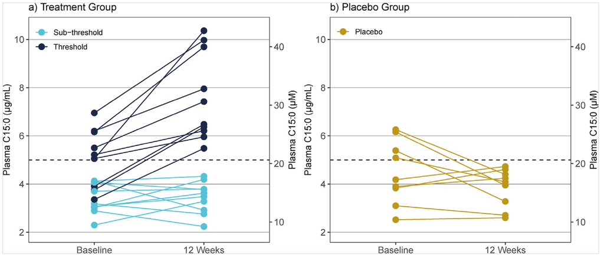

- 7 participants in treatment group were already above 5 μg/mL at baseline
- nobody in treatment group went from above to below threshold
- 4 in Placebo group were from above to below threshold
- Adherence per group:
  - **95%** Threshold group (171 total pills)
  - **84.3%** Sub-threshold group (152 total pills)
- 10 in treatment, despite taking on average 84.3% (152) of pills did not cross threshold

### C15:0 Plasma Level Increase

> [“In fact, Dr. Schwimmer’s study showed that the more total C15:0 supplementation a person took over the 12 week time period, the higher their C15:0 levels.”](https://fatty15.com/blogs/news/clinical-trial-supports-ability-for-fatty15-to-treat-emerging-nutritional-c15-0-deficiency-syndrome)
- Trial can’t establish a general rule that “the more total supplementation taken, the higher the levels.”
- This was not tested in the study. There was no dose-response analysis.

> [“Poor adherence to the daily fatty15 regimen explained about 80% of the difference between those who got up and over the **nutritionally sufficient threshold**.”](https://fatty15.com/blogs/news/clinical-trial-supports-ability-for-fatty15-to-treat-emerging-nutritional-c15-0-deficiency-syndrome)
- Study never states adherence explained 80% of difference. Unclear where this value comes from.
- “nutritionally sufficient threshold” language was not used in the study is not an externally validated standard.
- Study states: the adherence–response link was “not strong enough to explain the response heterogeneity alone”
- “This study was not designed or powered to expound further on this observation, and future studies will need to address these discrepancies.”

### Liver Function in Threshold Group

> “Among participants who adhered to the protocol, their C15:0 levels increased…This group with raised C15:0 levels also had significantly improved liver function (lower ALT and AST), as well as raised hemoglobin, demonstrating improved red blood cell function.”
- Reframing the threshold group as “participants who adhered to the protocol”.  
  Implies causality the study didn’t test.
- Study explicitly reports these as “preliminary associations” and “potentially relevant improvements…warranting further study,” not proven treatment effects.
- These results are part of a non-randomized post-hoc responder exploratory subgroup analysis and are associative only and do not establish causality or clinical efficacy.

### Subgroup Charts

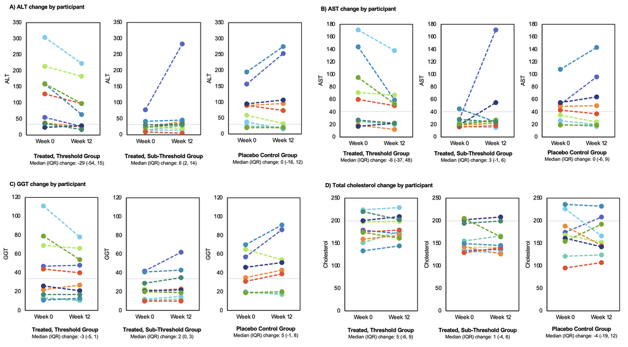

### Three Group Kruskal–Wallis Test

Study Abstract:

> “Half of the participants in the treatment group had a posttreatment C15:0 level >5 μg/mL. In these individuals, there were significantly greater decreases in alanine aminotransferase (−29 U/L, P = 0.001) and aspartate aminotransferase (−6 U/L, P = 0.014), as well as a greater increase in hemoglobin (0.60 g/dL, P = 0.010), **as compared with participants that did not reach a posttreatment level >5 μg/mL**.”
- P-values come from the three-group Kruskal–Wallis (KW) test
- Three-group KW test only answers: [“Are **any** of the three groups different?”](https://www.graphpad.com/guides/prism/latest/statistics/how_the_kruskal-wallis_test_works.htm), [**not which**](https://en.wikipedia.org/wiki/Kruskal–Wallis_test) groups differ.
- *“as compared with participants that did not reach >5 μg/mL”*: reads like a **specific two-group comparison** (≥5 μg/mL **vs** <5 μg/mL). [The KW test alone does **not** test that claim.](https://www.biostathandbook.com/kruskalwallis.html)
- You cannot just get a significant KW p-value, **look at medians** and declare “significantly greater decreases/increases in this group.”
- Would need **follow-up two-group test** for the exact comparison of interest.
- KW is based on ranks and can reflect differences in spread or tails, not just medians.
- The test is NOT adjusted for baseline levels of the groups.

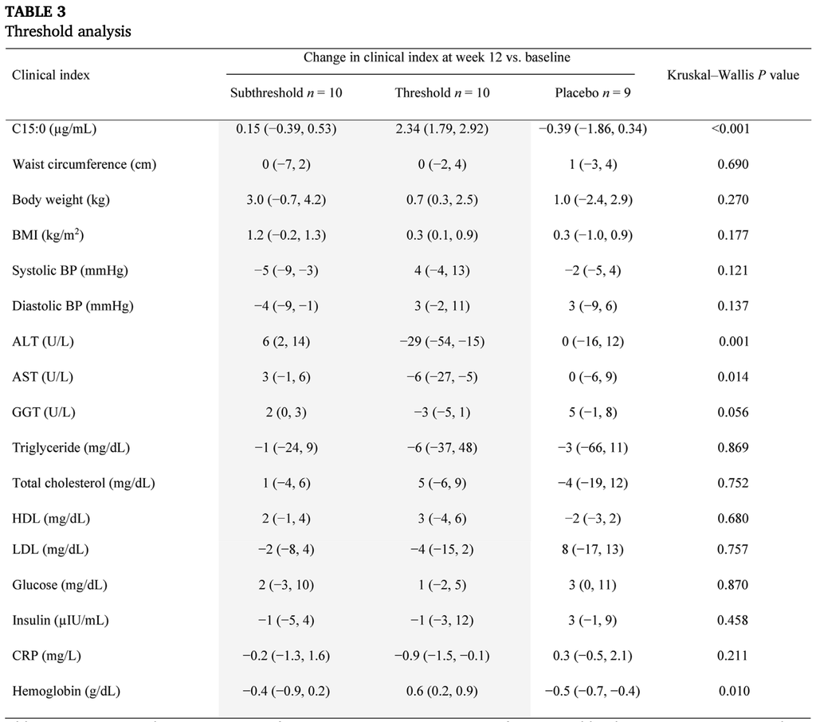

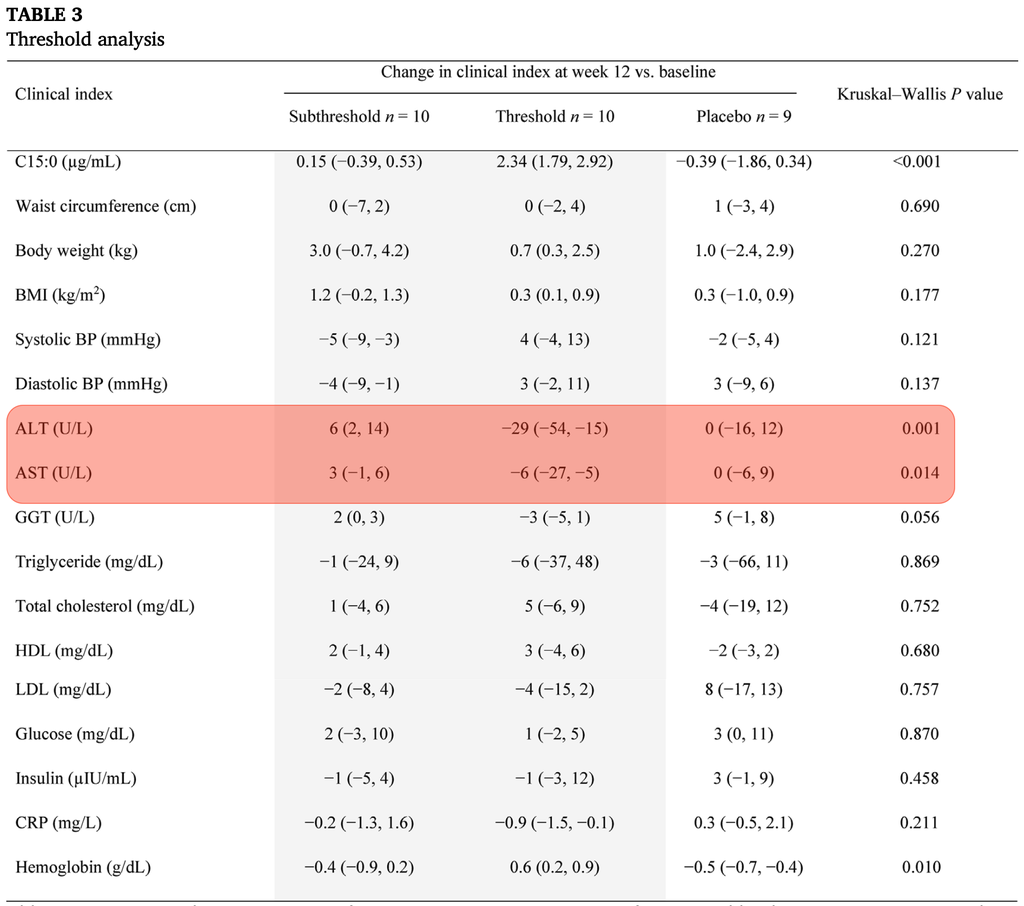

### Clinical Trial 3

**List of Metrics *unchanged* with addition of C15**:

Body weight, BMI, Waist circumference, Hip circumference,

Systolic blood pressure, Diastolic blood pressure,

Fasting glucose, Fasting insulin,

Total cholesterol, HDL cholesterol, LDL cholesterol, Triglycerides,

C-reactive protein (CRP), Alanine aminotransferase (ALT), Aspartate aminotransferase (AST), Hemoglobin

- Total Metrics measured: 17
- Metrics unchanged with fatty15: 16
- Metrics changed with fatty15: 1
- **it did on average increase C15 levels*

Note: in comparison (pre-threshold), GGT was found to be significantly lower in treatment group. In ‘threshold analysis’ it was NOT. At least one group differed for AST, ALT, and Hemoglobin.

### Clinical Trial 3: Conflicts of Interest

[**Seraphina Therapeutics** (and fatty15) was co-founded by Stephanie Venn-Watson](https://fatty15.com/pages/stephanie-venn-watson). They make fatty15.

> [“Among next-step studies is an ongoing double-blinded, placebo-controlled clinical trial with fatty15, which is being **independently conducted** by Dr. Jeffrey Schwimmer at the University of California, San Diego.”](https://fatty15.com/blogs/news/deep-dive-fatty15-vs-omega-3-study) - quote from fatty15 website

Clinical Trial 3 (published 2024)  
**Conflict of interest**: “JBS (Jeffrey Schwimmer) reports grants to UCSD from Intercept and Genfit. All other authors report no conflicts of interest.”  
**Funding**: “The project was also supported by **Seraphina Therapeutics** including the provision of C15:0 supplements and matching placebo.”

[2021 Study from J Clin Invest](https://pmc.ncbi.nlm.nih.gov/articles/PMC8670836/): “Jeffrey Schwimmer’s institution received research grants from Genfit, Intercept, and **Seraphina**.”

[2022 UC San Diego News Article](https://today.ucsd.edu/story/new-genetic-associations-in-pediatric-nafld-affect-both-risk-and-severity): “J.B.S. reports grants to UCSD from Intercept and **Seraphina** outside the submitted work”

[2023 Study from J P Gastro Nut](https://pmc.ncbi.nlm.nih.gov/articles/PMC10523882/): “Jeffrey B. Schwimmer received grants from Intercept, Genfit, and **Seraphina**.”

[2024 Study from Hepatology](https://www.cghjournal.org/article/S1542-3565%2823%2901041-8/pdf) Conflicts of interest:  
“Jeffrey Schwimmer’s institution received research grants from Genfit, Intercept, and **Seraphina**”

[2025 Study from J Clin Invest](https://pubmed.ncbi.nlm.nih.gov/40590222/) Conflict of interest:  
“JBS reports grant support to the University of California, San Diego, from **Seraphina Therapeutics** and Thiogenesis Therapeutics.”

## Fatty15 RCT: It does not reliably increase C15 levels. Benefits claimed were incorrectly stated and based on statistical shenanigans.

## From the 2 actual RCTs on C15: No replication of minor positive findings

### fatty15 on the Skeptics

**What the skeptics say**

> In videos, skeptics go over two clinical trials (Robinson et al. and Chooi et al.) and incorrectly conclude that these trials were not in relevant populations and did not demonstrate efficacy.

> Strangely, the skeptics made these statements while showing the papers’ abstracts, where the authors themselves concluded that C15:0 demonstrated promising results.

> The skeptics do not mention any of the other five studies and four clinical trials provided above, in part because two are recent publications.

### HOW MUCH?

Still want to try fatty15?

- ‘30 day’ means 30 pills, and 100mg per pill.
- Study protocol of 200mg or 300mg

To recreate the study doses:  
(based on 90 day subscription)

- $2.67 or $4.00 per day, or $80 or $120 per month
- note: *dose > 245mg per day is no longer GRAS*

What are you paying for? Marketing!

- “HSA/FSA eligible”

Unsure if you need fatty15?

There’s a $199 test for that!

Fatty15: Another Subscription!

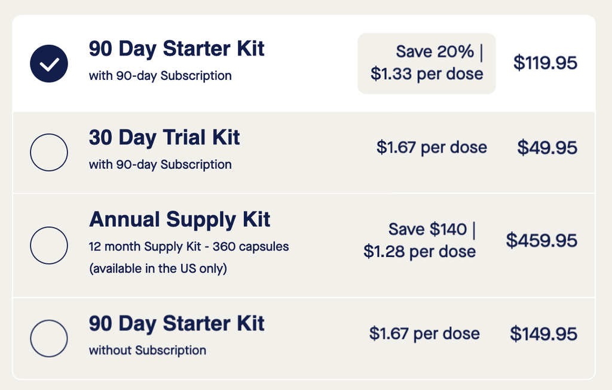

### Conclusion

In my view:

- Some observational studies suggest C15:0 may be beneficial, but others are null (no clear association).
- No human RCT evidence supplementation is worth taking
- Impossible to decouple the business and science
- Marketing is borderline harmful and potentially false advertising
- Marketing looks like parody or satire

# No New RCT Planned

### So Many Claims:

- **Sleep quality**  
  **Not supported (human):** No C15:0 sleep RCTs; “deeper sleep” appears in marketing/surveys. RCT found no difference in sleep duration. Example claim: [Product page](https://fatty15.com/products/your-essential-fatty-acid)
- **Hunger/satiety (PPAR-α)**  
  **Not supported (human):** No RCTs measuring appetite/energy intake/GLP-1/ghrelin.  
  Example claim: [Company post](https://fatty15.com/blogs/news/healthy-body-healthy-mind-how-our-bodies-use-c15-0-to-make-the-second-ever-discovered-full-acting-endocannabinoid)
- **Joint comfort**  
  **Not supported (human):** No human RCTs on joint pain/function.  
  Example claim: [Marketing copy](https://fatty15.com/blogs/news/fatty15-near-term-benefits-and-long-term-gains)
- **Gut microbiome**  
  **Limited/neutral (human):** In NAFLD (TANGO) trial, *Bifidobacterium adolescentis* increase reported with C15:0, but **no broader microbiome “health” or clinical GI benefits** established.  
  Source: [AJCN TANGO RCT](https://pubmed.ncbi.nlm.nih.gov/38035997/)
- **Anti-aging / “slows and reverses aging”**  
  **Not supported (human outcomes):** No RCTs on aging endpoints or epigenetic clocks; mortality association for 15:0 is **null** in meta-analysis.  
  Sources: [PLOS Med meta-analysis](https://journals.plos.org/plosmedicine/article?id=10.1371/journal.pmed.1003763), [Homepage claim](https://fatty15.com/), [“Reversing cellular aging” blog](https://fatty15.com/blogs/news/reversing-cellular-aging-with-fatty15)
- **“Reduces mTOR” (longevity mechanism)**  
  **Not supported (human):** Based on mechanistic/cell work, not human outcomes.  
  Sources: [Company mTOR blog](https://fatty15.com/blogs/news/what-it-mtor-link-to-longevity), [Review asserting AMPK↑/mTOR↓](https://pmc.ncbi.nlm.nih.gov/articles/PMC10649853/) is written by author and of questionable relevance.
- **“3× more cellular benefits than EPA (omega-3)” / “take fatty15 instead of omega-3”**  
  **Not supported (human); potentially misleading—arguably *borderline unethical*.** The “3×” figure comes incorrect math from a single **in-vitro** screen by company-affiliated authors; there are NO **human RCTs** or animal RCTs showing clinical superiority over EPA. Substitution messaging (implying you should take fatty15 **instead of** omega-3) conflicts with established recommendations that EPA/DHA remain important nutrients. Comparative health claims promoting substitution away from EPA/DHA **conflicts with consensus guidance** and, without competent and reliable human evidence, should be backed by **competent and reliable scientific evidence**, typically well-controlled human trials—which is not present here, a concern under [FTC health-claims standards](https://www.ftc.gov/system/files/ftc_gov/pdf/Health-Products-Compliance-Guidance.pdf).  
  Sources: [Company claim](https://fatty15.com/blogs/news/deep-dive-fatty15-vs-omega-3-study), [FTC Health Products Compliance Guidance](https://www.ftc.gov/system/files/ftc_gov/pdf/Health-Products-Compliance-Guidance.pdf), [NIH ODS: Omega-3](https://ods.od.nih.gov/factsheets/Omega3FattyAcids-HealthProfessional/), [AHA: Fish & omega-3](https://www.heart.org/en/healthy-living/healthy-eating/eat-smart/fats/fish-and-omega-3-fatty-acids)  
  *Note: This is a scientific/consumer-protection opinion, not legal advice or an allegation of unlawful conduct.*

### Vegans and C15 / C17. Fiber?

- Comparative analysis of fatty acid profiles across omnivorous, flexitarians, vegetarians, and vegans: insights from the NuEva study - “Conclusions:  
  The NuEva study revealed significant impact of dietary patterns on fatty acid profiles, with vegans and vegetarians displaying lower concentrations of SFA and n-3 fatty acids, including EPA and DHA, compared to omnivores and flexitarians.  
  Despite the **clear differences** in **fatty acid** profiles across the diets, the **inflammatory markers** measured in our healthy collective are **comparable**.”
- Odd-chain fatty acids as a biomarker for dietary fiber intake  
  **Results**:  
  Cellulose did not affect plasma OCFA levels, whereas inulin and propionate increased pentadecanoic acid (C15:0) by ∼17% (P < 0.05) and 13% (P = 0.05), respectively. The effect on heptadecanoic acid (C17:0) was even more pronounced, because it was elevated in almost all participants by inulin (11%; P < 0.01) and propionate (13%; P < 0.001). Furthermore, cell culture experiments showed a positive association between propionate and OCFA levels (R2 = 0.99, P < 0.0001), whereas palmitate (16:0) was negatively correlated (R2 = 0.83, P = 0.004).  
  **Conclusions**:  
  Our data show that gut-derived propionate is used for the hepatic synthesis of OCFAs in humans. The association of OCFAs with a decreased risk of type 2 diabetes may therefore also relate to dietary fiber intake and not only dairy fat.